# World's Gross Domestic Product (GDP) Exploration

### How is GDP and Population related with Income Class and Regions?

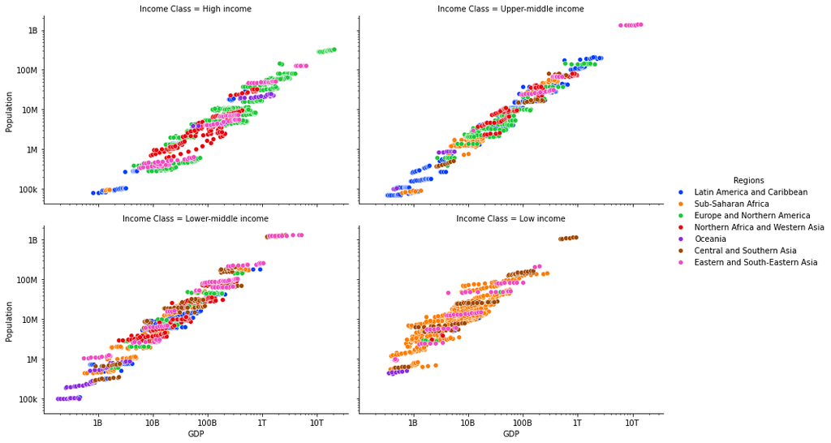

```python
# use facetgrid with income class as columns and regions as hue
fig = sb.FacetGrid(data=economy, col='Income Class', col_wrap=2, hue='Regions',
                 height=4, aspect=1.5, palette='bright')
fig.map(sb.scatterplot, 'GDP', 'Population', x_jitter=0.5)

plt.xscale('log')
plt.yscale('log')
fig.add_legend()

plt.xticks([10**9, 10**10, 10**11, 10**12, 10**13], ['1B', '10B', '100B', '1T', '10T'])
plt.yticks([10**5, 10**6, 10**7, 10**8, 10**9], ['100k', '1M', '10M', '100M', '1B'])

plt.xlabel('GDP')
plt.ylabel('Population');
```

The high income category is highly populated with points from Europe and Northern America, Eastern and South-Eastern Asia & Northern Africa and Western Asia. Scanty points can be seen for Latin America and Caribbean, Oceania and Sub_saharan Africa. There was a time when 100k indicated high income. No point is seen for Central and Southern Asia.

The upper middle income category has fair a distribution for all region types. Similarly with the lower middle income class.

The low income class is highly populated with points from Sub_saharan Africa & Central and Southern Asia. Scanty points can be seen for Europe and Northern America, Northern Africa and Western Asia, Latin America and Caribbean & Oceania. At this category, the highest GDP is less than 1T. This shows that the income class is constantly changing with the GDP and the world GDP continues to increase.

### How is Gross national expenditure and Gross savings related with Income Class and Regions?

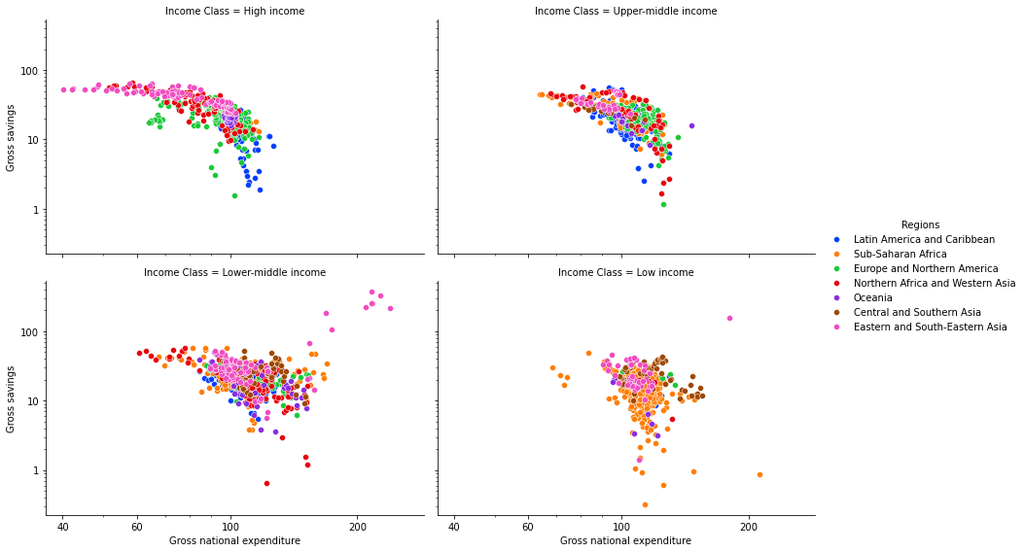

```python
# use facetgrid with income class as columns and regions as hue
fig = sb.FacetGrid(data=economy, col='Income Class', col_wrap=2, hue='Regions',
                 height=4, aspect=1.5, palette='bright')
fig.map(sb.scatterplot, 'Gross national expenditure', 'Gross savings', x_jitter=0.5)

plt.xscale('log')
plt.yscale('log')
fig.add_legend()

plt.xticks([4*10**1, 6*10**1, 10**2, 2*10**2], ['40', '60', '100', '200'])
plt.yticks([10**0, 10**1, 10**2], [1, 10, 100])

plt.xlabel('Gross national expenditure')
plt.ylabel('Gross savings')

plt.show()
```

For the lower middle income category, expenditure is slightly higher than savings. Some points in Eastern and South-Eastern Asia have outstandingly high savings and high expenditure.

For the low income category, expenditure tends to be higher than savings. This catgory is mainly populated with points from Sub-Saharan Africa, Central and Southern Asia and a bit of Eastern and South-Eastern Asia.

### How is Imports and Exports with Income Class and Regions?

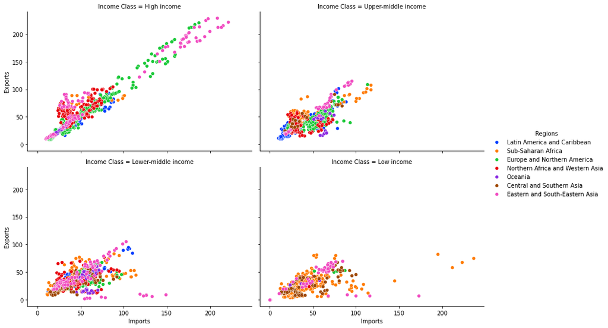

```python
# use facetgrid with income class as columns and regions as hue
fig = sb.FacetGrid(data=economy, col='Income Class', col_wrap=2, hue='Regions',
                 height=4, aspect=1.5, palette='bright')
fig.map(sb.scatterplot, 'Imports', 'Exports', x_jitter=0.5)

plt.xlabel('Imports')
plt.ylabel('Exports')

fig.add_legend()
plt.show()
```

For high income class, high export is associated with high imports especially in the Europe and Northern America & Eastern and South-Eastern Asia regions.

For the upper middle income class, import is slightly higher than exports and these are points in the Sub-Saharan Africa and scanty points from Europe and Northern America.

In lower middle income class, imports starts to get higher than exports especially for points in Sub-Saharan Africa, Europe and Northern America, Latin America and Caribbean.

In low income class, imports is clearly higher than exports. Regions like Europe and Northern America, Latin America and Caribbean, Northern Africa and Western Asia can barely be seen here.

This indicates that exports should be higher than import for high GDP.

### How is Inflation and Total natural resources with Income Class and Regions?

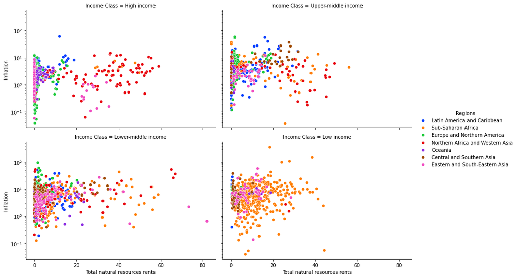

```python
# use facetgrid with income class as columns and regions as hue
fig = sb.FacetGrid(data=economy, col='Income Class', col_wrap=2, hue='Regions',
                 height=4, aspect=1.5, palette='bright')
fig.map(sb.scatterplot, 'Total natural resources rents', 'Inflation', x_jitter=0.5)

plt.yscale('log')
plt.xlabel('Total natural resources rents')
plt.ylabel('Inflation')

fig.add_legend()
plt.show()
```

Inflation and total natural resources are related in the sense that inflation affects the price at which natural resources produced in a country will be sold. As the income class goes from high to low, inflation increases from 0 to 100. However, there are points for the lowest and highest inflation values in both high and low income classes.

Lower middle income class seems to benefit more from natural resources with regions like Sub-Saharan Africa, Northern Africa and Western Asia & Eastern and South-Eastern Asia regions.

### How does GDP Per Capita vary by Income Class and Regions?

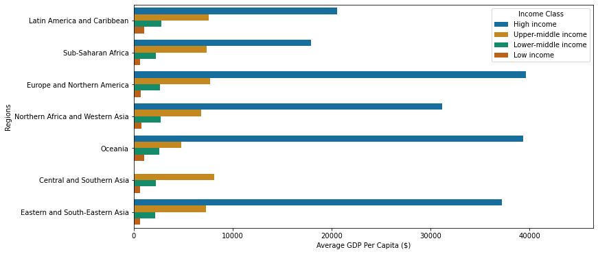

```python
plt.figure(figsize=(12,6))
sb.barplot(data=economy, y='Regions', x='GDP Per Capita', hue='Income Class', errwidth=0,
           palette='colorblind');
plt.xlabel('Average GDP Per Capita ($)');
```

Oceania is the region with the second highest GDP Per Capita despite having the lowest number of observations in the dataset. Conversly, Eastern and South-Eastern Asia is the region with the the highest population observations but and it has the third highest GDP Per Capita. This shows that high GDP is not entirely dependent on increase in population.

The average GDP Per Capita for the income classes have a close range excluding the high income class.

### Conclusion

### Talk about some of the relationships you observed in this part of the investigation. Were there features that strengthened each other in terms of looking at your feature(s) of interest?

> GDP and Population had a positive correlation but there were other factors that prevented GDP from increasing with population. Some of the regions with the highest population did not have the highest GDP.

## Conclusions

> The initial hypothesis was that high population would increase GDP which was confirmed to a certain extent but this was highly dependent on the other factors that contribute to GDP. As a whole, the correlation between GDP and exports followed the paradox of plenty theory (negative correlation) but by only examining how import and exports affected GDP, it obeyed the export-led growth (positive correlation).

> The world spends more on imports than exports. The income accrued from total natural resources make up a small percentage of the GDP. High inflation(above 10% annual change), and deflation have a negative effect on GDP.

> Also, the difference between the average GDP per Capita for high and upper middle income values is over a 100%. This raises the question of 'at what amount does income become high income?' and 'are the countries considered individually when being labelled as high or low income?'

## Limitations

> The dataset is outdated. I found out much later that I could have compiled a recent data from World bank.

> The dataset does not completely include all the countries in the world. Some features were missing for the countries that were present.